# 20-eda

let us take a look at our data before we start engineering features

exploring broad overview of data structure and dimensions

```r
dim(cl_appstore_games)
```

```
[1] 7561   14
```

```r
str(cl_appstore_games)
```

```
Classes ‘spec_tbl_df’, ‘tbl_df’, ‘tbl’ and 'data.frame':    7561 obs. of  14 variables:
 $ id                          : num  2.85e+08 2.85e+08 2.85e+08 2.86e+08 2.86e+08 ...
 $ name                        : chr  "Sudoku" "Reversi" "Morocco" "Sudoku (Free)" ...
 $ average_user_rating         : num  4 3.5 3 3.5 3.5 3 2.5 2.5 2.5 2.5 ...
 $ user_rating_count           : num  3553 284 8376 190394 28 ...
 $ price                       : num  2.99 1.99 0 0 2.99 0 0 0.99 0 0 ...
 $ in_app_purchases            : num  NA NA NA NA NA 1.99 NA NA NA NA ...
 $ developer                   : chr  "Mighty Mighty Good Games" "Kiss The Machine" "Bayou Games" "Mighty Mighty Good Games" ...
 $ age_rating                  : chr  "4+" "4+" "4+" "4+" ...
 $ languages                   : chr  "DA, NL, EN, FI, FR, DE, IT, JA, KO, NB, PL, PT, RU, ZH, ES, SV, ZH" "EN" "EN" "DA, NL, EN, FI, FR, DE, IT, JA, KO, NB, PL, PT, RU, ZH, ES, SV, ZH" ...
 $ size                        : num  15853568 12328960 674816 21552128 34689024 ...
 $ primary_genre               : chr  "Games" "Games" "Games" "Games" ...
 $ genres                      : chr  "Games, Strategy, Puzzle" "Games, Strategy, Board" "Games, Board, Strategy" "Games, Strategy, Puzzle" ...
 $ original_release_date       : Date, format: "2008-07-11" "2008-07-11" ...
 $ current_version_release_date: Date, format: "2017-05-30" "2018-05-17" ...
 - attr(*, "problems")=Classes ‘tbl_df’, ‘tbl’ and 'data.frame':    5185 obs. of  5 variables:
  ..$ row     : int  19 20 27 32 39 60 69 71 76 78 ...
  ..$ col     : chr  "In-app Purchases" "In-app Purchases" "In-app Purchases" "In-app Purchases" ...
  ..$ expected: chr  "no trailing characters" "no trailing characters" "no trailing characters" "no trailing characters" ...
  ..$ actual  : chr  ", 0.99, 1.99, 0.99, 4.99, 1.99, 1.99" ", 0.99, 0.99" ", 0.99, 0.99, 0.99" ", 0.99" ...
  ..$ file    : chr  "'data/appstore_games.csv'" "'data/appstore_games.csv'" "'data/appstore_games.csv'" "'data/appstore_games.csv'" ...
 - attr(*, "spec")=
  .. cols(
  ..   URL = col_character(),
  ..   ID = col_double(),
  ..   Name = col_character(),
  ..   Subtitle = col_character(),
  ..   `Icon URL` = col_character(),
  ..   `Average User Rating` = col_double(),
  ..   `User Rating Count` = col_double(),
  ..   Price = col_double(),
  ..   `In-app Purchases` = col_double(),
  ..   Description = col_character(),
  ..   Developer = col_character(),
  ..   `Age Rating` = col_character(),
  ..   Languages = col_character(),
  ..   Size = col_double(),
  ..   `Primary Genre` = col_character(),
  ..   Genres = col_character(),
  ..   `Original Release Date` = col_datetime(format = "%d/%m/%Y"),
  ..   `Current Version Release Date` = col_datetime(format = "%d/%m/%Y")
  .. )
```

let us look at the distributon of app prices

[figure not shown]

```r
cl_appstore_games %>%
  ggplot(aes(factor(average_user_rating),price))+
  geom_violin()
```

let us see how the violin plots look when we filter out NA values since we are using average_user_rating as our predictor, it makes sense to remove NA values

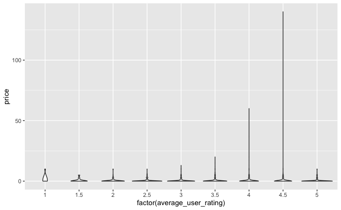

```r
cl_appstore_games %>%
  filter(!is.na(average_user_rating)) %>%
  ggplot(aes(factor(average_user_rating),price))+
  geom_violin()
```

hmm we still have really long tails. let us look a simple box plot to get an idea of the outliers

maybe look at using ggplotly(brushing)

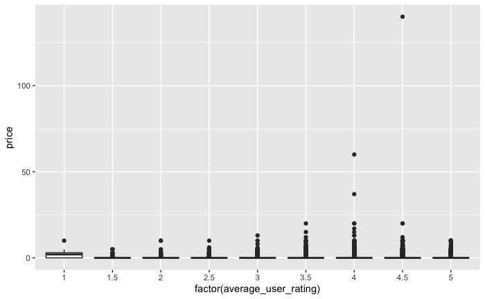

```r
cl_appstore_games %>%
  filter(!is.na(average_user_rating)) %>%
  group_by(average_user_rating) %>%
  ggplot(aes(factor(average_user_rating), price))+
  geom_boxplot()
```

hmmm we havent learned much about how to specifically deal with a large number of outliers yet. I am going to leave these in our dataset for now.

let us look at the average game rating by developer

```r
cl_appstore_games %>%
  group_by(developer) %>%
  summarise(avg_rating = mean(average_user_rating, na.rm=T)) %>%
  select(avg_rating, everything()) %>%
  arrange(desc(avg_rating))
```

| avg_rating | developer |
| --- | --- |
| 5.000000 | "It's All A Game LLC" |
| 5.000000 | \\u6df1\\u5733\\u54d4\\u5421\\u4e92\\u5a31\\u79d1\\u6280\\u6709\\u9650\\u516c\\u53f8 |
| 5.000000 | \\u70ed\\u95e8\\u6e38\\u620f |
| 5.000000 | 10K BULBS LLC |
| 5.000000 | 1791 Entertainment LLC |
| 5.000000 | 1C Mobile Ltd |
| 5.000000 | 99bosses |
| 5.000000 | A Dark Matter Creation LLC |
| 5.000000 | A Sharp, LLC |
| 5.000000 | Aashir Farooqi |

[output cut: 990 more lines]

let us look at the relationship between number of games a developer makes and the average rating

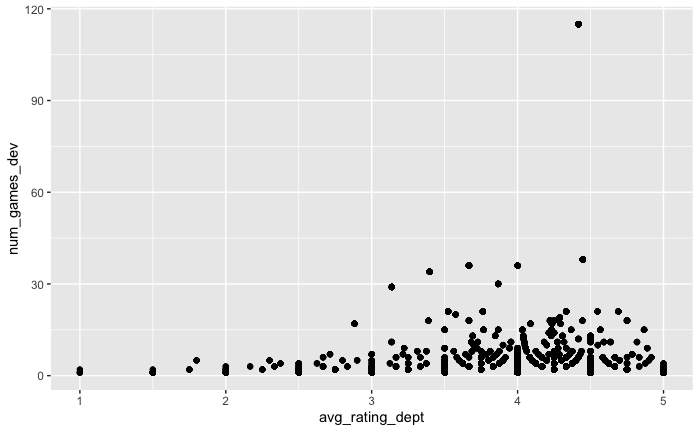

```r
cl_appstore_games %>%
  filter(!is.na(average_user_rating)) %>%
  group_by(developer) %>%
  mutate(num_games_dev = n(), avg_rating_dept = mean(average_user_rating, na.rm=T)) %>%
  ungroup() %>%
  arrange(desc(num_games_dev)) %>%
  select(num_games_dev,developer, average_user_rating,avg_rating_dept,everything()) %>%
  ggplot(aes(x=avg_rating_dept,y=num_games_dev))+
  geom_point()
```

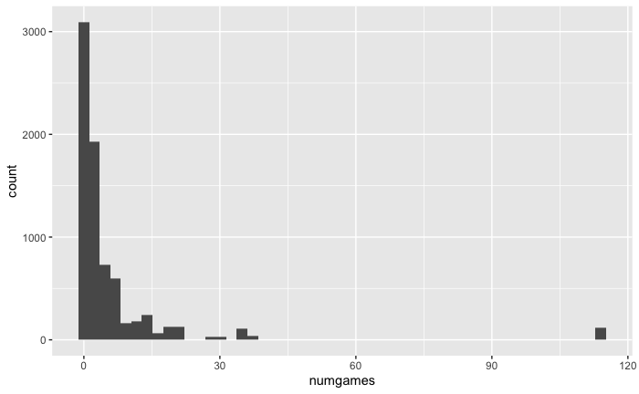

```r
cl_appstore_games %>%
  group_by(developer) %>%
  filter(!is.na(average_user_rating)) %>%
  mutate(numgames=n()) %>%
  ungroup() %>%
  filter(numgames>0) %>%
  select(numgames,average_user_rating,user_rating_count,everything()) %>%
  arrange(desc(average_user_rating, user_rating_count)) %>%
  ggplot(aes(numgames))+
  geom_histogram(bins =50)
```